# Flexible Correlation Structures for Random Effects

```r
setwd("C:/lme4")
options(digits = 3)
library(devtools)
library(ggplot2)
library(mvtnorm)
load_all()
```

```
## Loading lme4 Loading required namespace: lattice Loading required
## namespace: Matrix Loading required package: lattice Loading required
## package: Matrix Loading required namespace: splines Loading required
## namespace: nlme Loading required namespace: minqa
```

```r
source("misc/reGenerators_flexLambda.R", echo = TRUE)
```

```
##
## > d <- function(formula, iid = FALSE) {
## +     mkReTrmDiagonal <- local({
## +         bar <- formula[[2]][[2]]
## +         iid <- iid
## +         function(fr .... [TRUNCATED]
##
## > cs <- function(formula, init = NULL, het = TRUE) {
## +     if (het) {
## +         mkReTrmCSHet <- local({
## +             bar <- formula[[2]][[2]]
## +       .... [TRUNCATED]
```

```r
flexLmer <- function(formula, data, specials = c("cs", "d"), verbose = 0L) {
    # split off reGenerator terms:
    frmlterms <- terms(formula, specials = specials)
    termnames <- attr(frmlterms, "variables")
    where.specials <- unlist(attr(frmlterms, "specials")) - 1  #offset by one since response is counted
    lmerformula <- formula(paste(formula[[2]], "~", paste(attr(frmlterms, "term.labels")[-where.specials],
        collapse = "+")))
    reGenerators <- as.formula(paste("~", paste(attr(frmlterms, "term.labels")[where.specials],
        collapse = "+")))
    # see example(modular)
    lmod <- lFormula(lmerformula, data, reGenerators = reGenerators)
    devfun <- do.call(mkLmerDevfun, lmod)
    opt <- optimizeLmer(devfun, verbose = verbose)
    # FIXME: this should not be necessary...
    environment(devfun)$pp$theta <- opt$par
    list(model = mkMerMod(environment(devfun), opt, lmod$reTrms, fr = lmod$fr),
        opt = opt, devfun = devfun)
}
```

### Diagonal random effects:

Uncorrelated random effects for different factor levels without having to manually specify dummies for each level:

Example data: Different variances for different treatment levels

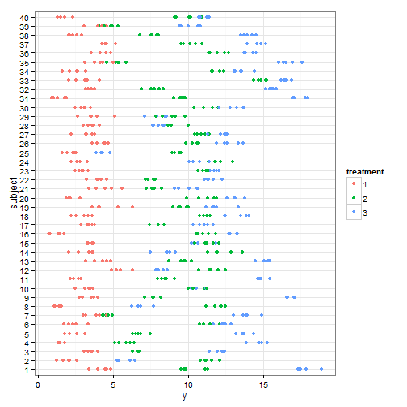

```r
## sim & plot data:
set.seed(2323)
nsubj <- 40
nreps <- 5
ntreat <- 3
n <- ntreat * nsubj * nreps
data <- expand.grid(treatment = factor(1:ntreat), reps = 1:5, subject = factor(1:nsubj))
sd.treat <- 1:ntreat
sd.eps <- 0.5
beta <- (3 * 1:ntreat)
data <- within(data, {
    mu <- model.matrix(~treatment, data) %*% beta + model.matrix(~0 + subject:treatment,
        data) %*% rnorm(nsubj * ntreat, sd = rep(sd.treat, e = nsubj))
    y <- mu + rnorm(n, sd = sd.eps)
})
(p <- qplot(x = subject, y = y, col = treatment, data = data) + theme_bw() +
    coord_flip())
```

Fit & check results (estimates overlaid as crosses):

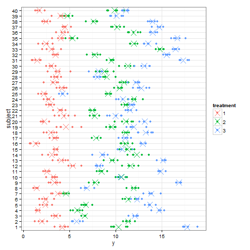

```r
m <- flexLmer(y ~ treatment + d(~(0 + treatment | subject)), data)
mOld <- lmer(y ~ treatment + (0 + treatment | subject), data)
# --> sd(treatment2)!

p + geom_point(aes(y = fitted(m$model)), shape = 4, size = 5)
```

True variance components: [1, 2, 3, 0.5]

Estimated: [1.004, 2.316, 3.167, 0.523]

True beta: [3, 6, 9]

Estimated: [3.167, 6.407, 9.089]

Compare:

```r
mOld
```

```
## Linear mixed model fit by REML ['lmerMod']
## Formula: y ~ treatment + (0 + treatment | subject)
##    Data: data
##
## REML criterion at convergence: 1433
##
## Random effects:
##  Groups   Name       Variance Std.Dev. Corr
##  subject  treatment1  1.009   1.004
##           treatment2  0.179   0.423    -0.853
##           treatment3 15.214   3.900     0.586 -0.564
##  Residual             0.274   0.523
## Number of obs: 600, groups: subject, 40
##
## Fixed effects:
##             Estimate Std. Error t value
## (Intercept)    3.167      0.163    19.4
## treatment2     6.407      0.424    15.1
## treatment3     9.089      0.517    17.6
##
## Correlation of Fixed Effects:
##            (Intr) trtmn2
## treatment2 -0.515
## treatment3 -0.250  0.004
```

### Variance homogeneous random effects:

Uncorrelated random effects with *same* variance for different factor levels.

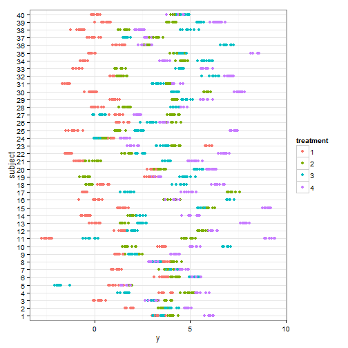

```r
## sim & plot
set.seed(1480)
nsubj <- 40
nreps <- 10
ntreat <- 4
n <- ntreat * nsubj * nreps
data <- expand.grid(treatment = factor(1:ntreat), reps = 1:nreps, subject = factor(1:nsubj))
sd.treat <- 2
sd.eps <- 0.2
beta <- 1:ntreat

data <- within(data, {
    mu <- model.matrix(~treatment, data) %*% beta + model.matrix(~0 + subject:treatment,
        data) %*% rnorm(ntreat * nsubj, sd = sd.treat)
    y <- mu + rnorm(n, sd = sd.eps)
})
(p2 <- qplot(x = subject, y = y, col = treatment, group = subject, data = data) +
    theme_bw() + coord_flip())
```

Fit & check results:

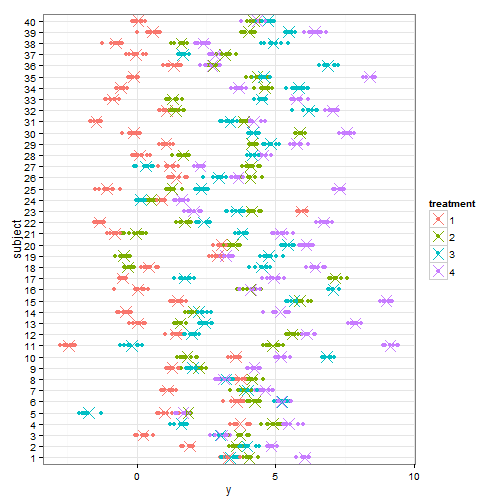

```r
m2 <- flexLmer(y ~ treatment + d(~(0 + treatment | subject), iid = TRUE), data)
m2Old <- lmer(y ~ treatment + (0 + treatment | subject), data)

p2 + geom_point(aes(y = fitted(m2$model)), shape = 4, size = 5)
```

True variance components: [2, 0.2]

Estimated: [1.888, 0.197]

True beta: [1, 2, 3, 4]

Estimated: [0.896, 2.278, 2.701, 4.103]

Compare:

```r
m2Old
```

```
## Linear mixed model fit by REML ['lmerMod']
## Formula: y ~ treatment + (0 + treatment | subject)
##    Data: data
##
## REML criterion at convergence: 461
##
## Random effects:
##  Groups   Name       Variance Std.Dev. Corr
##  subject  treatment1  9.9503  3.154
##           treatment2  1.5685  1.252    -0.994
##           treatment3  7.2418  2.691     0.650 -0.564
##           treatment4 10.3146  3.212    -0.447  0.365 -0.803
##  Residual             0.0388  0.197
## Number of obs: 1600, groups: subject, 40
##
## Fixed effects:
##             Estimate Std. Error t value
## (Intercept)    0.896      0.499    1.80
## treatment2     2.278      0.749    3.04
## treatment3     2.701      0.791    3.41
## treatment4     4.103      0.907    4.52
##
## Correlation of Fixed Effects:
##            (Intr) trtmn2 trtmn3
## treatment2 -0.929
## treatment3 -0.917  0.863
## treatment4 -0.950  0.913  0.892
```

… way too many theta's for these data.

### Compound symmetry random effects (heterogeneous variances):

I.e., Correlated random effects with *same* correlation between different effects.

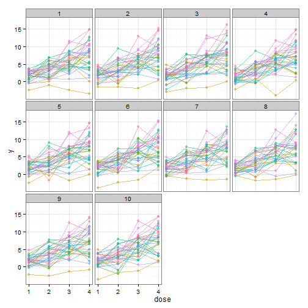

```r
## sim & plot
set.seed(2013)
nsubj <- 30
nreps <- 10
ndose <- 4
n <- nsubj * nreps * ndose
data <- expand.grid(reps = factor(1:nreps), dose = 1:ndose, subject = factor(1:nsubj))

# set up cov.mat for random effects (i.e., variance increases with dose,
# subject-deviations positively correlated):
sd.dose <- 1:ndose
cor <- 0.5
S <- {
    C <- diag(ndose)
    C[upper.tri(C)] <- C[lower.tri(C)] <- cor
    sd.dose * t(sd.dose * C)
}
sd.eps <- 1
beta <- 2

data <- within(data, {
    y <- dose * beta + model.matrix(~0 + as.factor(dose):subject) %*% as.vector(replicate(nsubj,
        rmvnorm(1, sigma = S)[1, ])) + rnorm(n, sd = sd.eps)
    doseF <- as.factor(dose)
    subjectreps <- subject:reps
})
(p3 <- qplot(x = dose, y = y, col = subject, data = data, geom = c("point",
    "line"), alpha = 0.2, facets = ~reps) + theme_bw() + theme(legend.position = "none"))
```

Fit & check results:

```r
m3 <- flexLmer(y ~ dose + cs(~(0 + doseF | subject)), data)
m3Old <- lmer(y ~ dose + (0 + doseF | subject), data)

# true random effect covariance:
S
```

```
##      [,1] [,2] [,3] [,4]
## [1,]  1.0    1  1.5    2
## [2,]  1.0    4  3.0    4
## [3,]  1.5    3  9.0    6
## [4,]  2.0    4  6.0   16
```

```r
# estimated:
(estS <- with(environment(m3$devfun), {
    Lt <- pp$Lambdat
    Lt@x <- pp$thfun(m3$opt$par)
    crossprod(Lt[1:ndose, 1:ndose])
}) * sigma(m3$model)^2)
```

```
## 4 x 4 sparse Matrix of class "dsCMatrix"
##
## [1,] 1.34 1.10 1.39  1.92
## [2,] 1.10 4.66 2.60  3.59
## [3,] 1.39 2.60 7.50  4.55
## [4,] 1.92 3.59 4.55 14.32
```

True correlation: 0.5, estimated as 0.439.

True error sd: 1, estimated as 0.999.

True beta: [0, 2], estimated as [-0.224, 1.916].

Compare:

```r
m3Old
```

```
## Linear mixed model fit by REML ['lmerMod']
## Formula: y ~ dose + (0 + doseF | subject)
##    Data: data
##
## REML criterion at convergence: 3849
##
## Random effects:
##  Groups   Name   Variance Std.Dev. Corr
##  subject  doseF1  1.363   1.168
##           doseF2  0.694   0.833    0.994
##           doseF3 10.302   3.210    0.603 0.672
##           doseF4 15.619   3.952    0.429 0.466 0.645
##  Residual         0.999   1.000
## Number of obs: 1200, groups: subject, 30
##
## Fixed effects:
##             Estimate Std. Error t value
## (Intercept)   -0.236      0.261   -0.91
## dose           1.901      0.171   11.13
##
## Correlation of Fixed Effects:
##      (Intr)
## dose -0.585
```

sd(doseF2) is way off!

### Compound symmetry random effects (homogeneous variances):

I.e., correlated random effects with *identical* correlations between different effects.

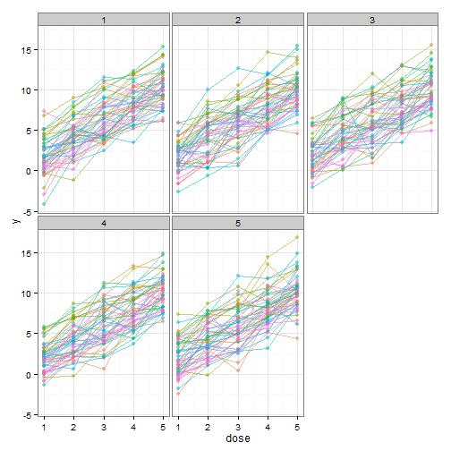

```r
## sim & plot
set.seed(2121)
nsubj <- 50
nreps <- 5
ndose <- 5
n <- nsubj * nreps * ndose
data <- expand.grid(reps = factor(1:nreps), dose = 1:ndose, subject = factor(1:nsubj))

# set up cov.mat for random effects (i.e., variance constant for doses,
# subject-deviations positively correlated):
sd.dose <- 2
cor <- 0.8
S <- {
    C <- diag(ndose)
    C[upper.tri(C)] <- C[lower.tri(C)] <- cor
    sd.dose * t(sd.dose * C)
}
sd.eps <- 1
beta <- 2

data <- within(data, {
    y <- dose * beta + model.matrix(~0 + as.factor(dose):subject) %*% as.vector(replicate(nsubj,
        rmvnorm(1, sigma = S)[1, ])) + rnorm(n, sd = sd.eps)
    doseF <- as.factor(dose)
    subjectreps <- subject:reps
})
(p4 <- qplot(x = dose, y = y, col = subject, data = data, geom = c("point",
    "line"), alpha = 0.2, facets = ~reps) + theme_bw() + theme(legend.position = "none"))
```

NB: for this data with such a strong correlation between the dose-specific random intercepts simply doing `~(1|subject)` would probably make more sense…

Fit & check results:

```r
m4 <- flexLmer(y ~ dose + cs(~(0 + doseF | subject), het = FALSE), data)
m4Old <- lmer(y ~ dose + (0 + doseF | subject), data)
```

True variance components & correlation: 2, 0.8, 1

Estimates: 2.025, 0.799, 0.994

True betas: 0, 2

Estimates: 0.061, 2.006

Compare:

```r
m4Old
```

```
## Linear mixed model fit by REML ['lmerMod']
## Formula: y ~ dose + (0 + doseF | subject)
##    Data: data
##
## REML criterion at convergence: 4136
##
## Random effects:
##  Groups   Name   Variance Std.Dev. Corr
##  subject  doseF1 2.123    1.457
##           doseF2 3.570    1.890    0.639
##           doseF3 3.458    1.860    0.632 0.837
##           doseF4 2.110    1.453    0.784 0.662 0.923
##           doseF5 6.519    2.553    0.222 0.335 0.240 0.162
##  Residual        0.976    0.988
## Number of obs: 1250, groups: subject, 50
##
## Fixed effects:
##             Estimate Std. Error t value
## (Intercept)  -0.0824     0.2446    -0.3
## dose          2.0499     0.0610    33.6
##
## Correlation of Fixed Effects:
##      (Intr)
## dose -0.613
```

### TODOs

- **for all of these cases I get the 'assertion failure' crash reported earlier if I set `nreps <- 1`!!**
- fix need for manual assignment of `theta` into `environment(devfun)`
- `VarCorr`methods etc. for sensible output and summaries
- more structures:
  - AR(1), at least for discrete time
  - effects with fixed correlation structure \( C \): \( b_i \sim N_k(0, \sigma^2 C) \), where \( C \) comes from some measure of spatial/temporal/genetic/… distance.
  - diagonal covariance where \( \sigma_{ij}=\exp(x_{ij}\beta) \) or similar, i.e. covariate-dependent.

### System setup:

Using 'flexLambda' branch!

```r
Sys.Date()
```

```
## [1] "2013-08-18"
```